# Week 4 Assignment

Emma Colley

10/01/2020

# Topic

Rent Burden in Massachusetts

*Examining Gross Rent as a Percentage of Household Income against four other variables*

# Variables

*Continuous*

1. Age of Individual (AGEP)
2. Number of People in Household (NP)
3. Gross Household Income (HINCP)

*Categorical*

1. Race/Ethnicity (RAC1P)
2. Highest Level of Education Received (SCHL)

## Loading Libraries

```r
library(tidyverse)
library(dbplyr)
library(dplyr)
library(jtools)
library(interactions)
library(knitr)
```

## Loading Data

I am going to re-code some data into fewer categories. Please note that for the purposes of this exercise I have grouped American Indian, Alaska Native, Native Hawaiian, Pacific Islander and Native tribes into one category. I understand I would want to be more critical about grouping racial identities in future analysis. I have also grouped education levels together, including Bachelors, Masters and Doctorate degree recipients. I understand there are major differences between the three and would break this down under other circumstances.

```r
person_data <- read_csv("rent_burden_massachusetts_v3.csv") %>%

mutate(EDU = case_when(
    SCHL_label=="1 or more years of college credit, no degree"~"HS Diploma",
    SCHL_label=="12th grade - no diploma"~"HS Diploma",
    SCHL_label=="Associate's degree"~"Assoc. Degree",
    SCHL_label=="Bachelor's degree"~"Bach Degree or Higher",
    SCHL_label=="Doctorate degree"~"Bach Degree or Higher",
    SCHL_label=="GED or alternative credential"~"HS Diploma",
    SCHL_label=="Grade 10"~"1No HS",
    SCHL_label=="Grade 11"~"1No HS",
    SCHL_label=="Grade 1"~"1No HS",
    SCHL_label=="Grade 2"~"1No HS",
    SCHL_label=="Grade 3"~"1No HS",
    SCHL_label=="Grade 4"~"1No HS",
    SCHL_label=="Grade 5"~"1No HS",
    SCHL_label=="Grade 6"~"1No HS",
    SCHL_label=="Grade 7"~"1No HS",
    SCHL_label=="Grade 8"~"1No HS",
    SCHL_label=="Grade 9"~"1No HS",
    SCHL_label=="Kindergarten"~"1No HS",
    SCHL_label=="Master's degree"~"Bach Degree or Higher",
    SCHL_label=="No schooling completed"~"1No HS",
    SCHL_label=="Nursery school, preschool"~"1No HS",
    SCHL_label=="Professional degree beyond a bachelor's degree"~"Bach Degree or Higher",
    SCHL_label=="Regular high school diploma"~"HS Diploma",
    SCHL_label=="Some college, but less than 1 year"~"HS Diploma"),

RACE = case_when(
    RAC1P_label=="American Indian alone"~"Native Am.",
    RAC1P_label=="American Indian and Alaska Native tribes specified; or American Indian or Alaska Native, not specified and no other races"~"Native Am.",
    RAC1P_label=="Asian alone"~"Asian",
    RAC1P_label=="Black or African American alone"~"Black",
    RAC1P_label=="Native Hawaiian and Other Pacific Islander alone"~"Native Am.",
    RAC1P_label=="Some Other Race alone"~"Other Race",
    RAC1P_label=="Two or More Races"~"Multiracial",
    RAC1P_label=="White alone"~"1White"))
```

## Original Linear Regression

Below is the linear regression I ran last week. The dependent variable is Gross Rent as a Percentage of Household Income. The independent variables are education level, race. age of person and number of people in the household.

```r
model1 <- lm(GRPIP ~ EDU + RACE + AGEP + NP,
            data = person_data)

summary(model1)
```

```
##
## Call:
## lm(formula = GRPIP ~ EDU + RACE + AGEP + NP, data = person_data)
##
## Residuals:
##     Min      1Q  Median      3Q     Max
## -36.125 -11.969  -4.419   6.972  75.003
##
## Coefficients:
##                           Estimate Std. Error t value Pr(>|t|)
## (Intercept)              39.887140   0.868523  45.925  < 2e-16 ***
## EDUAssoc. Degree         -5.229010   0.797713  -6.555 5.77e-11 ***
## EDUBach Degree or Higher -8.695419   0.575215 -15.117  < 2e-16 ***
## EDUHS Diploma            -3.146645   0.547474  -5.748 9.25e-09 ***
## RACEAsian                 3.121303   0.596580   5.232 1.70e-07 ***
## RACEBlack                 2.785634   0.542295   5.137 2.84e-07 ***
## RACEMultiracial           2.393221   0.851052   2.812  0.00493 **
## RACENative Am.           -4.890339   2.961429  -1.651  0.09869 .
## RACEOther Race            2.610134   0.670054   3.895 9.85e-05 ***
## AGEP                     -0.014633   0.009619  -1.521  0.12824
## NP                       -1.884364   0.121329 -15.531  < 2e-16 ***
## ---
## Signif. codes:  0 '***' 0.001 '**' 0.01 '*' 0.05 '.' 0.1 ' ' 1
##
## Residual standard error: 17.97 on 13142 degrees of freedom
## Multiple R-squared:  0.04425,    Adjusted R-squared:  0.04352
## F-statistic: 60.85 on 10 and 13142 DF,  p-value: < 2.2e-16
```

## Adding A Variable to Improve Model Fit

First, I’m going to add in an independent variable to try for a better model fit. I’m doing this at the recommendation of Catherine. I think it will be meaningful to add in Household Income. We can see that as your household income increases by $1, you pay 0.0001 percentage points less of your income on rent. This is statistically significant. By adding in this independent variable, my Multiple R-squared value increased from 0.044 to 0.267. I will keep this additional variable in further studies.

```r
model2 <- lm(GRPIP ~ HINCP + EDU + RACE + AGEP + NP,
            data = person_data)

summary(model2)
```

```
##
## Call:
## lm(formula = GRPIP ~ HINCP + EDU + RACE + AGEP + NP, data = person_data)
##
## Residuals:
##     Min      1Q  Median      3Q     Max
## -35.335 -10.052  -3.678   5.545  77.252
##
## Coefficients:
##                            Estimate Std. Error t value Pr(>|t|)
## (Intercept)               4.279e+01  7.625e-01  56.114  < 2e-16 ***
## HINCP                    -1.230e-04  1.952e-06 -63.027  < 2e-16 ***
## EDUAssoc. Degree         -1.720e+00  7.013e-01  -2.452  0.01421 *
## EDUBach Degree or Higher  1.294e-01  5.232e-01   0.247  0.80462
## EDUHS Diploma            -1.250e+00  4.807e-01  -2.600  0.00934 **
## RACEAsian                 2.845e+00  5.228e-01   5.442 5.36e-08 ***
## RACEBlack                 1.030e+00  4.760e-01   2.164  0.03046 *
## RACEMultiracial           1.145e+00  7.461e-01   1.535  0.12478
## RACENative Am.           -4.841e+00  2.595e+00  -1.866  0.06213 .
## RACEOther Race            7.226e-01  5.879e-01   1.229  0.21910
## AGEP                     -3.554e-02  8.436e-03  -4.212 2.54e-05 ***
## NP                       -2.037e-01  1.096e-01  -1.858  0.06321 .
## ---
## Signif. codes:  0 '***' 0.001 '**' 0.01 '*' 0.05 '.' 0.1 ' ' 1
##
## Residual standard error: 15.75 on 13141 degrees of freedom
## Multiple R-squared:  0.2661, Adjusted R-squared:  0.2655
## F-statistic: 433.2 on 11 and 13141 DF,  p-value: < 2.2e-16
```

## Converting a continuous variable to a categorical variable

My multiple R-squared value went from 0.267 to 0.268, so no major change there. This is technically a better model fit but not by a significant amount.

```r
person_data <- person_data %>%
  mutate(age_cat = case_when(AGEP <= 25 ~ "younger",
                               AGEP > 25 ~ "older"))

model3 <- lm(GRPIP ~ HINCP + EDU + RACE + age_cat + NP,
            data = person_data)

summary(model3)
```

```
##
## Call:
## lm(formula = GRPIP ~ HINCP + EDU + RACE + age_cat + NP, data = person_data)
##
## Residuals:
##     Min      1Q  Median      3Q     Max
## -36.503 -10.005  -3.576   5.554  76.055
##
## Coefficients:
##                            Estimate Std. Error t value Pr(>|t|)
## (Intercept)               4.049e+01  5.183e-01  78.119  < 2e-16 ***
## HINCP                    -1.222e-04  1.950e-06 -62.662  < 2e-16 ***
## EDUAssoc. Degree         -1.490e+00  6.979e-01  -2.135   0.0327 *
## EDUBach Degree or Higher  4.698e-01  5.051e-01   0.930   0.3523
## EDUHS Diploma            -1.160e+00  4.757e-01  -2.438   0.0148 *
## RACEAsian                 2.884e+00  5.222e-01   5.522 3.41e-08 ***
## RACEBlack                 1.091e+00  4.756e-01   2.294   0.0218 *
## RACEMultiracial           1.201e+00  7.439e-01   1.614   0.1065
## RACENative Am.           -4.691e+00  2.592e+00  -1.809   0.0704 .
## RACEOther Race            9.079e-01  5.862e-01   1.549   0.1214
## age_catyounger            2.534e+00  3.748e-01   6.762 1.42e-11 ***
## NP                       -1.812e-01  1.052e-01  -1.723   0.0850 .
## ---
## Signif. codes:  0 '***' 0.001 '**' 0.01 '*' 0.05 '.' 0.1 ' ' 1
##
## Residual standard error: 15.73 on 13141 degrees of freedom
## Multiple R-squared:  0.2677, Adjusted R-squared:  0.267
## F-statistic: 436.6 on 11 and 13141 DF,  p-value: < 2.2e-16
```

# Adding an interaction term

Finally, let’s add an interaction term. I am hypothesizing that Race (independent variable) has an effect on Household Income (other independent variable) when considering how much of their income ones pays on rent. This could come from systemic racial inequalities and/or social or cultural norms. Here I will try to capture that effect.

The negative and statistically significant coefficient for Household Income (HINCP) tells us that as one’s income increases, they pay fewer percentage points of their household income on rent. This is controlling for all other variables. When you look at Household Income interacting with Race, the coefficients are a mix of positive and negative.

The R-squared value increases slightly from 0.268 to 0.273. This is the best fit so far.

```r
model4 <- lm(GRPIP ~ HINCP + EDU + RACE + age_cat + NP +
               HINCP:RACE,
            data = person_data)

summary(model4)
```

```
##
## Call:
## lm(formula = GRPIP ~ HINCP + EDU + RACE + age_cat + NP + HINCP:RACE,
##     data = person_data)
##
## Residuals:
##     Min      1Q  Median      3Q     Max
## -37.559  -9.924  -3.512   5.594  85.826
##
## Coefficients:
##                            Estimate Std. Error t value Pr(>|t|)
## (Intercept)               4.002e+01  5.271e-01  75.925  < 2e-16 ***
## HINCP                    -1.212e-04  2.239e-06 -54.144  < 2e-16 ***
## EDUAssoc. Degree         -1.301e+00  6.959e-01  -1.870 0.061562 .
## EDUBach Degree or Higher  6.790e-01  5.042e-01   1.347 0.178119
## EDUHS Diploma            -1.005e+00  4.745e-01  -2.118 0.034187 *
## RACEAsian                 1.659e+00  7.662e-01   2.165 0.030378 *
## RACEBlack                 4.661e-01  6.502e-01   0.717 0.473455
## RACEMultiracial           4.439e+00  1.172e+00   3.789 0.000152 ***
## RACENative Am.           -3.444e+00  4.457e+00  -0.773 0.439745
## RACEOther Race            6.805e+00  9.008e-01   7.554 4.49e-14 ***
## age_catyounger            2.513e+00  3.736e-01   6.726 1.81e-11 ***
## NP                       -9.180e-02  1.052e-01  -0.872 0.383008
## HINCP:RACEAsian           1.136e-05  5.532e-06   2.054 0.040040 *
## HINCP:RACEBlack           8.407e-06  6.022e-06   1.396 0.162718
## HINCP:RACEMultiracial    -4.109e-05  1.143e-05  -3.596 0.000324 ***
## HINCP:RACENative Am.     -1.539e-05  4.443e-05  -0.346 0.729059
## HINCP:RACEOther Race     -9.228e-05  1.065e-05  -8.668  < 2e-16 ***
## ---
## Signif. codes:  0 '***' 0.001 '**' 0.01 '*' 0.05 '.' 0.1 ' ' 1
##
## Residual standard error: 15.68 on 13136 degrees of freedom
## Multiple R-squared:  0.2731, Adjusted R-squared:  0.2722
## F-statistic: 308.4 on 16 and 13136 DF,  p-value: < 2.2e-16
```

## Comparing the R-Squared Values

Model 4 is the best fitting model. I added an independent variable, changed an independent variable from continuous to categorical and added an interaction term. The R-squared values increased *very* slightly after model 2 (when I added in another variable) but the last model is the best fitting nonetheless.

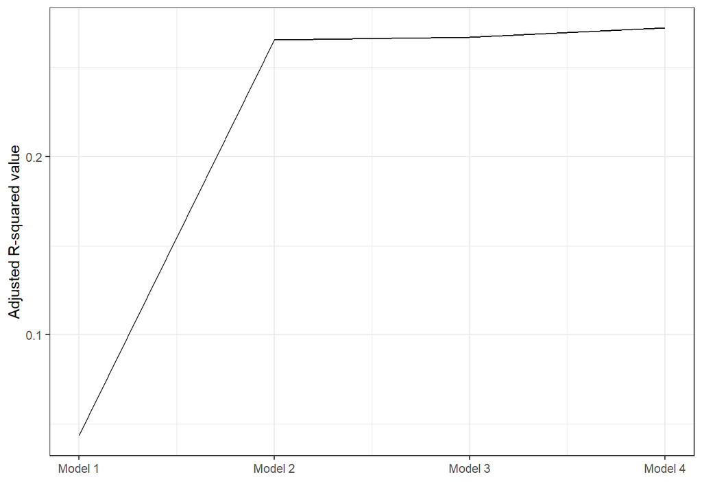

```r
ModelFit <- tibble(model = c(1, 2, 3, 4),
                   R_square = c(summary(model1)$adj.r.squared,
                                summary(model2)$adj.r.squared,
                                summary(model3)$adj.r.squared,
                                summary(model4)$adj.r.squared))

ggplot(ModelFit, aes(x = model, y = R_square)) +
  geom_line() +
  scale_x_continuous(name = "",
                   breaks = breaks <- seq(1, 4, by = 1),
                   labels = paste("Model", breaks)) +
  scale_y_continuous(name = "Adjusted R-squared value") +
  theme_bw()
```

## Plotting Model 4

[output not shown]

[output not shown]

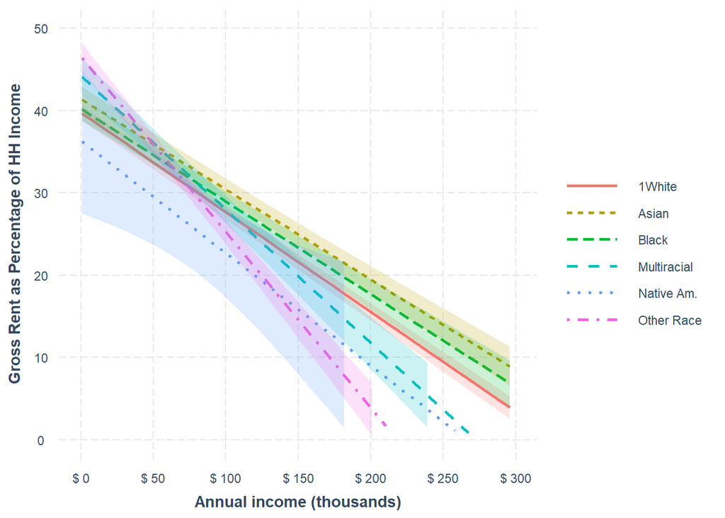

```r
interact_plot(model4, pred = HINCP, modx = RACE, interval = TRUE) +
  scale_x_continuous(name = "Annual income (thousands)", limits = c(0,300000), breaks = breaks <- seq(0,300000, by = 50000), labels = paste("$", prettyNum(breaks/1000, big.mark = "'"))) +
  scale_y_continuous(name = "Gross Rent as Percentage of HH Income", limits = c(0,50), breaks =seq(0,50, by = 10)) +
  scale_color_discrete(name = "") +
  scale_linetype_discrete(name = "") +
  scale_fill_discrete(name = "")
```